# BBets Project

Dottie

1/31/2020

# Introduction

The question is how much money is won/lost on a bet that at least two people have the same birthday in a class of 35. Instructor wagers 2:1.

Instructor has done this 15 times.

1. What is his expected win/loss amount?
2. How much would the instructor have to wager to make the bet fair?
3. How many students would have to be in the class for a 2:1 bet to be fair?

# Question 1

```r
daysOne = 1:365

studentsOne = 35
classesOne = 15
runsOne = studentsOne*classesOne
payoutOne = 2

saveArrayOne = vector('numeric')
for (k in 1:1000) {


  bankOne = 0
  for (i in 1:runsOne) {

    sampleClassOne = sample(daysOne, studentsOne, replace = TRUE)

    repeats = length(unique(sampleClassOne))

    if (repeats == studentsOne) bankOne = bankOne - payoutOne
    else bankOne = bankOne + 1
  }

saveArrayOne[k] = bankOne
}
```

Histogram of bank amounts.

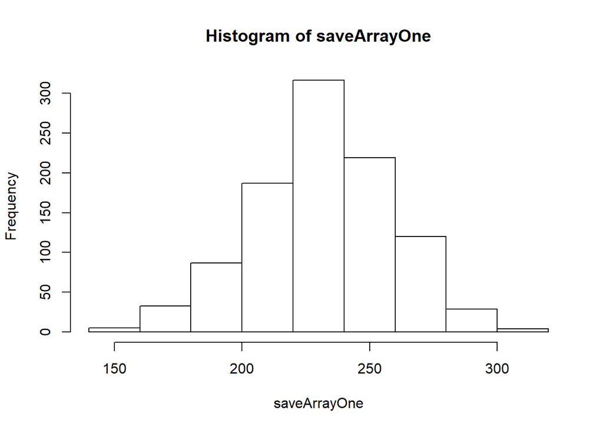

```r
hist(saveArrayOne)
```

Professor made money every time because there are no negatives in the histogram.

Answer to number 1: what is his expected win/loss amount?

```r
print('average amt:')
```

```
## [1] "average amt:"
```

```r
print(mean(saveArrayOne))
```

```
## [1] 232.062
```

# Question 2

```r
daysTwo = 1:365

studentsTwo = 35
classesTwo = 15
runsTwo = studentsTwo*classesTwo
payoutTwo = 4.5

saveArrayTwo = vector('numeric')
for (k in 1:1000) {


  bankTwo = 0
  for (i in 1:runsTwo) {

    sampleClassTwo = sample(daysTwo, studentsTwo, replace = TRUE)

    repeats = length(unique(sampleClassTwo))

    if (repeats == studentsTwo) bankTwo = bankTwo - payoutTwo
    else bankTwo = bankTwo + 1
  }

saveArrayTwo[k] = bankTwo
}
```

Histogram of bank amounts.

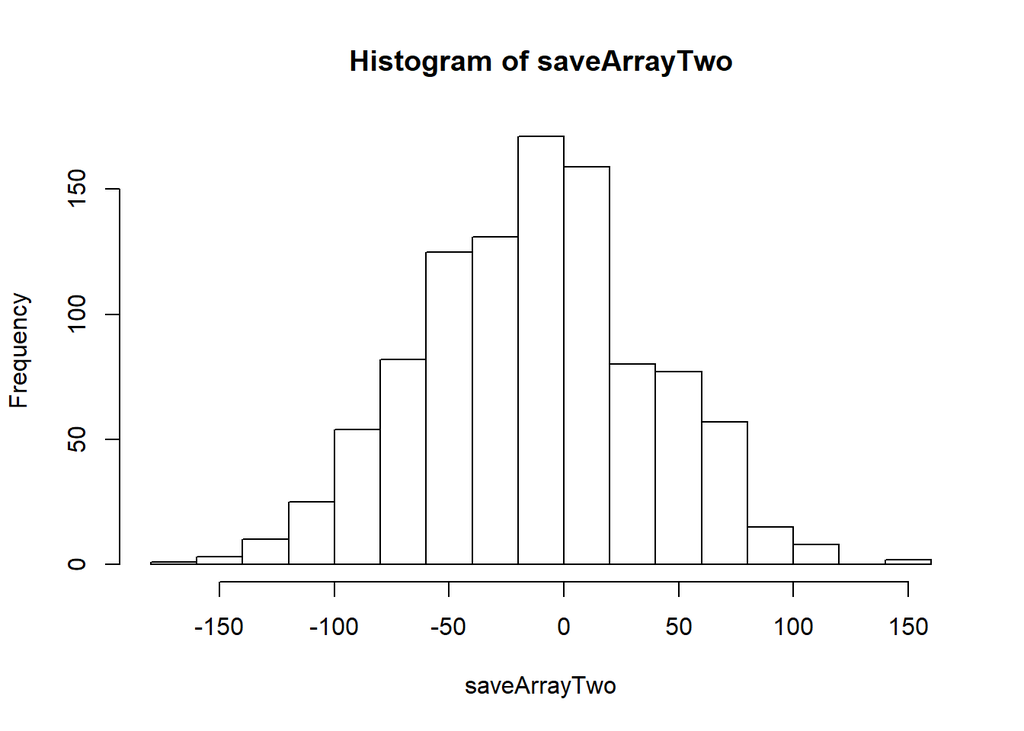

```r
hist(saveArrayTwo)
```

Answer to number 2: How much would the instructor have to wager to make the bet fair?

The instructor would need to bet 4 dollars and 50 cents for the bet to be fair.

# Question 3

```r
daysThree = 1:365

studentsThree = 28
classesThree = 15
runsThree = studentsThree*classesThree
payoutThree = 2

saveArrayThree = vector('numeric')
for (k in 1:1000) {


  bankThree = 0
  for (i in 1:runsThree) {

    sampleClassThree = sample(daysThree, studentsThree, replace = TRUE)

    repeats = length(unique(sampleClassThree))

    if (repeats == studentsThree) bankThree = bankThree - payoutThree
    else bankThree = bankThree + 1
  }

saveArrayThree[k] = bankThree
}
```

Histogram of bank amounts.

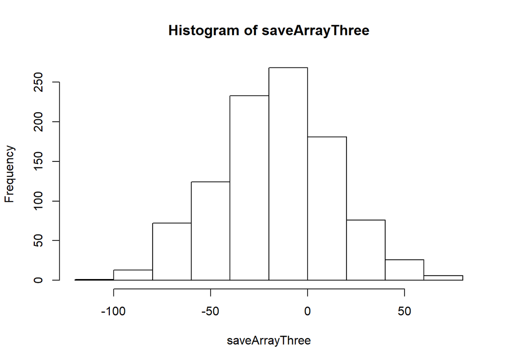

```r
hist(saveArrayThree)
```

Answer to number 3: How many students would have to be in the class for a 2:1 bet to be fair?

The class size must be around 28 students for it to be fair.